### Q0: Sampling and Distribution

You are studying the population of a specific type of marine algae in different locations. Assume the algal density is normally distributed. You take samples from two locations (Location A and Location B) to compare the algae populations. Generate synthetic data to represent the algal density (individuals per square meter) at these two locations. Assume a mean density of 200 and 220 individuals/m^2 with a common standard deviation of 20 individuals/m^2 for both locations, with 50 samples from each location.

```r
A <- rnorm(50,200,20)
A
```

```
##  [1] 208.5515 191.7529 206.2381 185.2746 147.7363 242.3975 197.6958 254.6379
##  [9] 154.4855 210.3088 196.5741 234.7110 190.9067 163.4635 229.9029 177.2186
## [17] 218.0661 199.6352 184.5291 196.5299 188.5376 170.8653 186.4477 208.0652
## [25] 185.5423 209.6095 191.2634 229.2747 162.2971 203.6485 232.7417 192.5009
## [33] 191.1763 189.7591 165.5224 194.0909 204.2720 206.7871 193.7441 166.7464
## [41] 197.3212 192.1675 183.8718 204.8160 224.2490 238.6790 195.2134 158.8510
## [49] 215.4302 217.8888
```

```r
B <- rnorm(50,220,20)
B
```

```
##  [1] 232.2425 233.2504 206.9768 215.4844 213.7580 213.7603 242.2609 182.6834
##  [9] 220.7763 227.5058 226.8758 209.8248 189.4004 210.1998 265.7985 253.4990
## [17] 200.4545 237.1950 239.0149 234.5504 228.6590 228.7553 232.9932 247.6645
## [25] 238.0532 225.1834 271.4539 232.3790 197.5614 218.7961 213.6287 173.7529
## [33] 185.1045 211.9937 211.2506 221.8114 215.2519 199.8078 237.7227 216.5482
## [41] 228.1557 188.1389 219.1468 232.5506 237.5087 212.6097 222.2026 221.1024
## [49] 228.6577 190.3796
```

### Q1: Data Cleaning

Check your dataset for any outliers.

```r
data <- data.frame(Site = rep(c("A", "B"),each = 50),
                   Algae= c(A,B))
data
```

```
##     Site    Algae
## 1      A 208.5515
## 2      A 191.7529
## 3      A 206.2381
## 4      A 185.2746
## 5      A 147.7363
## 6      A 242.3975
## 7      A 197.6958
## 8      A 254.6379
## 9      A 154.4855
## 10     A 210.3088
## 11     A 196.5741
## 12     A 234.7110
## 13     A 190.9067
## 14     A 163.4635
```

[output cut: 86 more lines]

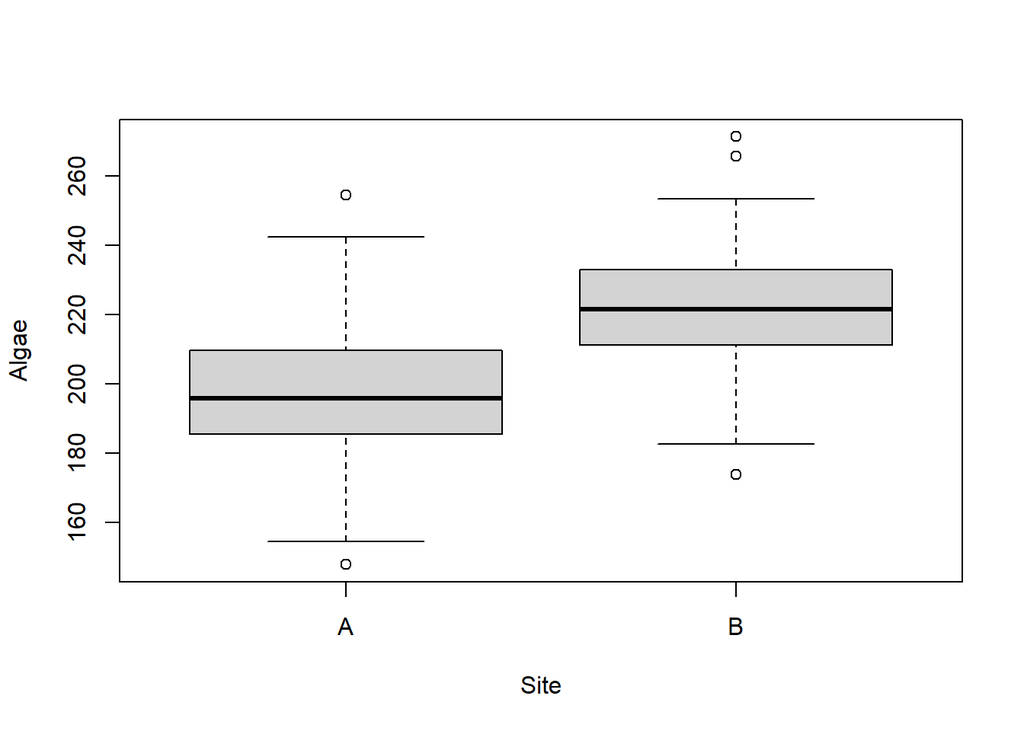

```r
boxplot(Algae~Site,data=data)
```

```r
outliers_A <- boxplot.stats(A)$out
outliers_A
```

```
## [1] 147.7363 254.6379
```

```r
outliers_B <- boxplot.stats(B)$out
outliers_B
```

```
## [1] 265.7985 271.4539 173.7529
```

```r
data_selection <- data[!(data$Site == "A" & data$Algae %in% outliers_A) &
                     !(data$Site == "B" & data$Algae %in% outliers_B), ]
data_selection
```

```
##     Site    Algae
## 1      A 208.5515
## 2      A 191.7529
## 3      A 206.2381
## 4      A 185.2746
## 6      A 242.3975
## 7      A 197.6958
## 9      A 154.4855
## 10     A 210.3088
## 11     A 196.5741
## 12     A 234.7110
## 13     A 190.9067
## 14     A 163.4635
## 15     A 229.9029
## 16     A 177.2186
```

[output cut: 81 more lines]

### Q2: Visualization and Kernel Density Estimation (KDE)

Plot a Kernel Density Estimation (geom_density plot) to visualize the distribution of algal densities at both locations.

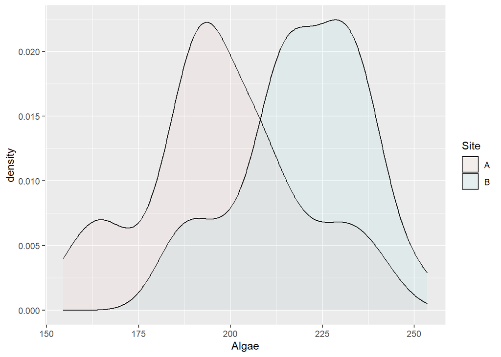

```r
library(ggplot2)
ggplot(data_selection, aes(x = Algae, fill = Site))+
  geom_density(alpha=0.05)
```

### Q3: Binomial Distribution

Suppose in a new survey, at each location, you take 10 random samples and in each sample, you identify whether a particular species of marine algae is present or not. Assume the probability of finding this species in a sample is 0.7 at Location A and 0.5 at Location B.

Simulate this scenario using a binomial distribution, and compare the probability of finding the species in at least 7 out of 10 samples at both locations.

```r
Sample_A <- rbinom(10,1,0.7)
Sample_A
```

```
##  [1] 1 1 1 0 0 1 0 1 0 1
```

```r
Sample_B <- rbinom(10,1,0.5)
Sample_B
```

```
##  [1] 1 1 1 0 1 0 1 1 1 0
```

```r
result_A <- sum(Sample_A) >= 7
result_A
```

```
## [1] FALSE
```

```r
result_B <- sum(Sample_B) >= 7
result_B
```

```
## [1] TRUE
```

### Q4: Poisson Distribution

Imagine a scenario where you are studying the occurrences of a particular rare marine event, such as the sighting of a rare marine species, over a set period at a specified location. Assume the average rate of occurrence is 3 per month.

Utilize a Poisson distribution to calculate the probability of observing exactly 5 occurrences in a month, and the probability of observing 3 or fewer occurrences in a month.

```r
prob_5 <- dpois(5, 3)
prob_5
```

```
## [1] 0.1008188
```

```r
prob_3_or_fewer <- ppois(3,3)
prob_3_or_fewer
```

```
## [1] 0.6472319
```

### Q5:

consider the following two lists.

```r
list1 <- c(44.40, 47.70, 65.59, 50.71, 51.29, 67.15, 54.61, 37.35, 43.13, 45.54, 62.24, 53.60, 54.01, 51.11,
           44.44, 67.87, 54.98, 30.33, 57.01, 45.27, 39.32, 47.82, 39.74, 42.71, 43.75, 33.13, 58.38, 51.53,
           38.62, 62.54, 54.26, 47.05, 58.95, 58.78, 58.22, 56.89, 55.54, 49.38, 46.94, 46.20, 43.05, 47.92,
           37.35, 71.69, 62.08, 38.77, 45.97, 45.33, 57.80, 49.17, 52.53, 49.71, 49.57, 63.69, 47.74, 65.16,
           34.51, 55.85, 51.24, 52.16, 53.80, 44.98, 46.67, 39.81, 39.28, 53.04, 54.48, 50.53, 59.22, 70.50,
           45.09, 26.91, 60.06, 42.91, 43.12, 60.26, 47.15, 37.79, 51.81, 48.61, 50.06, 53.85, 46.29, 56.44,
           47.80, 53.32, 60.97, 54.35, 46.74, 61.49, 59.94, 55.48, 52.39, 43.72, 63.61, 44.00, 71.87, 65.33,
           47.64, 39.74)

list2 <- c(44.34, 48.85, 41.30, 39.79, 30.73, 44.32, 33.23, 19.98, 39.30, 58.78, 36.37, 54.12, 20.73, 44.17,
           52.79, 49.52, 46.59, 35.39, 32.25, 29.64, 46.76, 30.79, 37.64, 41.16, 72.66, 35.22, 48.53, 46.17,
           30.57, 43.93, 66.67, 51.77, 45.62, 38.66, 14.20, 61.97, 23.09, 56.10, 73.64, 23.34, 55.53, 41.07,
           21.42, 22.28, 20.98, 37.04, 23.07, 55.32, 76.50, 25.69, 56.82, 56.54, 49.98, 29.87, 43.21, 40.79,
           53.44, 39.41, 59.65, 39.38, 60.79, 29.26, 26.10, 93.62, 38.75, 49.47, 54.55, 37.74, 52.75, 50.53,
           41.77, 45.98, 44.49, 76.93, 33.88, 28.56, 45.57, 49.66, 51.55, 38.12, 29.05, 63.95, 39.76, 32.02,
           41.46, 42.04, 61.65, 46.27, 56.31, 37.51, 48.22, 40.13, 46.42, 31.57, 25.34, 74.96, 54.01, 26.23,
           35.83, 27.22)
```

These list were generated using the following code

set.seed(123) # Setting a seed for reproducibility list1 <- round(rnorm(100, mean = 50, sd = 10), 2) # Generating 100 values from a normal distribution list2 <- round(rnorm(100, mean = 45, sd = 15), 2) # Generating 100 values from another normal distribution

Compare the distributions of these two lists to determine if they originate from the same distribution or from different distributions.

1. Use geom_density to create a density plot for each list on the same graph. Use different colors to distinguish between the two lists:

```r
data_list <- data.frame(Group = factor(c(rep("List 1",length(list1)),
                                         rep("List 2",length(list2)))),
                        Values = c(list1,list2))
data_list
```

```
##      Group Values
## 1   List 1  44.40
## 2   List 1  47.70
## 3   List 1  65.59
## 4   List 1  50.71
## 5   List 1  51.29
## 6   List 1  67.15
## 7   List 1  54.61
## 8   List 1  37.35
## 9   List 1  43.13
## 10  List 1  45.54
## 11  List 1  62.24
## 12  List 1  53.60
## 13  List 1  54.01
## 14  List 1  51.11
```

[output cut: 186 more lines]

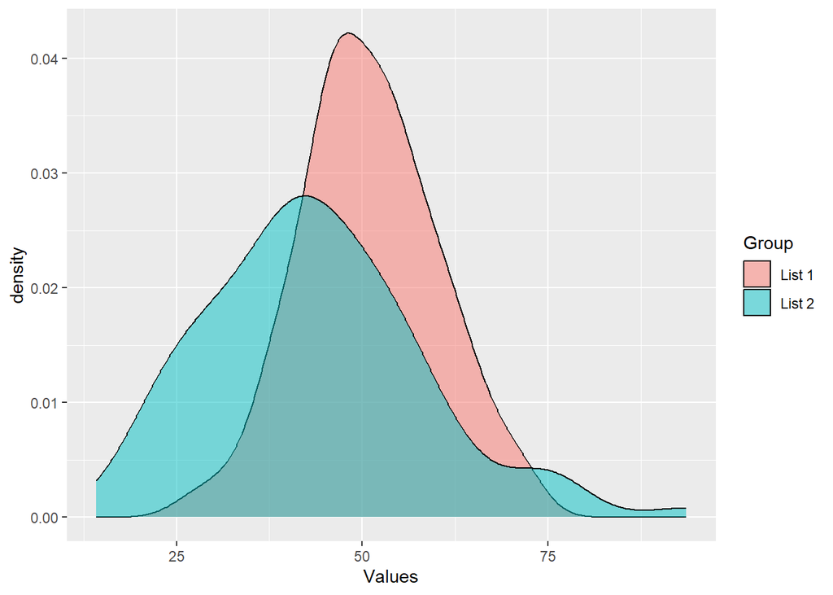

```r
ggplot(data_list, aes (x = Values, fill = Group))+
  geom_density(alpha=0.5)
```

Examine the plot you have generated. Do you think list1 and list2 come from the same distribution or different distributions? Why? Write down your observations and reasoning.